# Kahviseminaari 20.8. 2019

## Lyhyt sisällys

- Tutkimuksen aihe ja sijoittuminen
- Aineisto ja lähestymistapa
- Poimintoja tuloksista
- Konkreettisia esimerkkejä

Я вчера поймал во-о-от такую щуку!

minä eilen napata-PRET - tälainen hauki-ACC

Huhtikuusta 1999 SaiPan päävalmentajana toiminut Mansikka, 41, valmensi aikaisemmin seuran A-juniorijoukkuetta kolme vuotta.

## Tutkimusaineistosta

[interactive chart not shown]

## Yleistason tuloksia

- alkusijainti, keskisijainti, loppusijainti
- oletussijainti
- lauseen alku vs. loppu
- tilastollinen malli: ilmauskohtaiset erot + epäsuora evidenssi

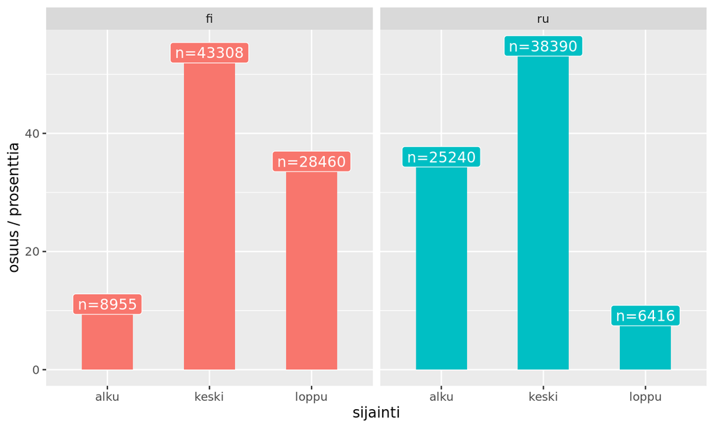

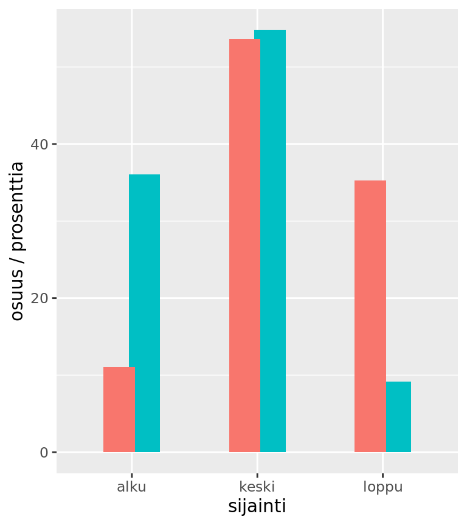

- morfologinen rakenne
- semanttinen funktio (11 kpl)
- positionaalisuus
- numeraalin läsnäolo

## Esimerkki: Johdantokonstruktio

[figure not shown]

- Positionaaliset ilmaukset
- Deiktiset päivännimet (erit. eilen)
- simultaaninen funktio

В среду Госдума на очередном пленарном заседании рассмотрит ситуацию в Ливии.

PREP keskiviikko-PREP duuma PREP seuraava-PREP täysi-PREP istunto-PREP käsitellä-FUT-p3 tilanne-ACC PREP Libya-PREP

'[Keskiviikkona] duuma [täysi-istunnossaan] käsittelee Libyan tilannetta.'

https://newdaynews.ru/moskow/325004.html

## Viikonpäivien vasempia kollokaatteja

| Suomi Kollokaatti | Suomi Frek. | Suomi Suht. frek. | Venäjä Kollokaatti | Venäjä Frek. | Venäjä Suht. frek. |
| --- | --- | --- | --- | --- | --- |
| tänään | 10 | 10.2 % | — | 561 | 67.03 % |
| viime | 10 | 10.2 % | что | 22 | 2.63 % |
| ja | 6 | 6.12 % | а | 19 | 2.27 % |
| mutta | 6 | 6.12 % | вечером | 11 | 1.31 % |
| sillä | 5 | 5.1 % | ранее | 11 | 1.31 % |
| viimeksi | 5 | 5.1 % | уже | 10 | 1.19 % |
| eilen | 4 | 4.08 % | однако | 9 | 1.08 % |
| jo | 4 | 4.08 % | утром | 9 | 1.08 % |
| vielä | 4 | 4.08 % | так | 6 | 0.72 % |
| aiemmin | 3 | 3.06 % | вот | 5 | 0.6 % |

Вчера вторая ракетка Открытого чемпионата Франции Мария Шарапова провела свой первый матч на парижских грунтовых кортах.

eilen toinen tennispelaaja avoin-GEN mestaruuskilpailu-GEN Ranska-GEN Marija Šarapova suorittaa-PRET POSS ensimmäinen-ACC ottelu-ACC PREP pariisilaiset-PREP massa-PREP kentät-PREP

‘[eilen] Ranskan avoimen tennisturnauksen toiseksi sijoitettu pelaaja Marija Šarapova pelasi ensimmäisen ottelunsa Pariisin massakentillä.’

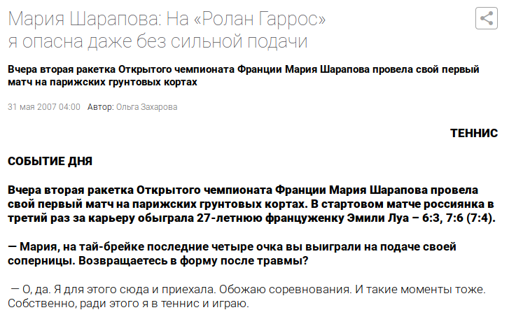

### Sijainti (\(y\))

- alku
- keski
- loppu

### Selittävät muuttujat (\(x\))

- Lähdekorpuksen tyyppi
- subjektin pituus
- Uuden esittelyyn viittaava verbi?
- Eilen vs. viime viikolla vs. viime vuonna
- Kieli

## Muita esimerkkejä (lyhyesti)

- Mansikka, 41, valmensi aikaisemmin seuran A-juniorijoukkuetta kolme vuotta.
- Yli kolme miljoonaa opiskelijaa on saanut Erasmus-apurahaa vuodesta 1987 lähtien.
- Oppositio sätti niin hallituksen talouslinjan kuin säästötkin budjettikeskustelussa eduskunnassa keskiviikkona.

## Väitöskirja

[figure not shown]

http://urn.fi/URN:ISBN:978-952-03-1106-3 (trepo.tuni.fi)